# Section D: Impact and Implications of COVID-specific Policies/Funds

Alex Liu

December 15, 2021

- Note 12/14
  - change percent to count
  - D1 fix labels
  - D2
  - D3 explore student groups used by districts
  - D4 generate figures

# D.1 EquityAnalysisToolName

> Summarize the frequency, bar chart, the categories of EquityAnalysisToolName, by unit of districts
- 305 school districts with 271 equity analysis tool names
  - many names are similar. are they the same?
  - see equityana.xlsx & equitytoolkeywords.csv

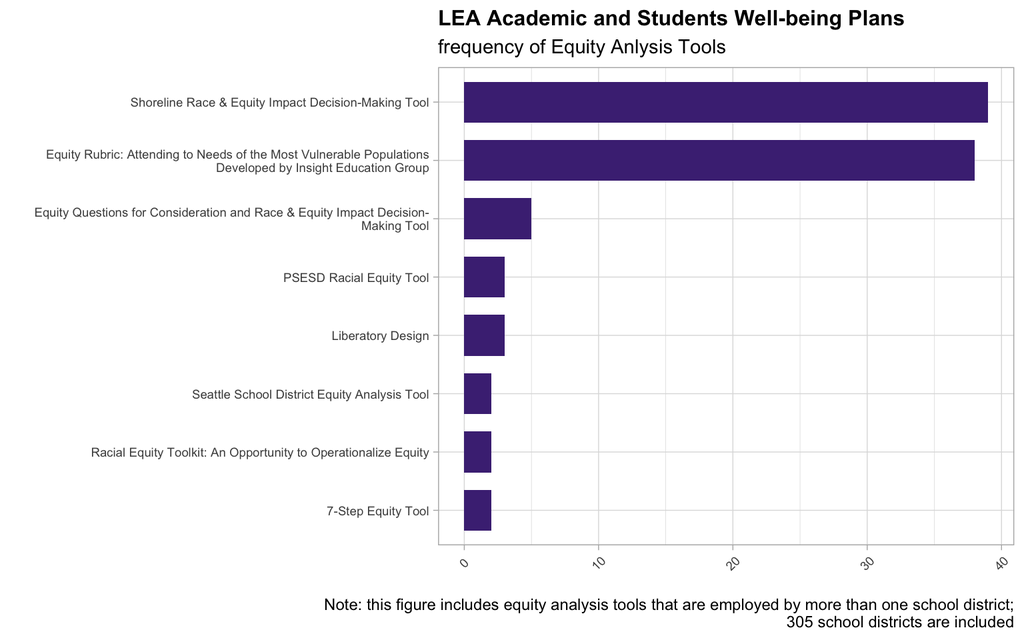

# D.2 UniversalSupports

> Summarize the frequency of the categories of “UniversalSupports” (Bar chart), by unit of districts
- delete “Other - Write In (Required)”?
- “AVID” = “AVID 6-12”? “College in the High School + AVID”?
- separate narratives?
  - “Here in the Kahlotus School District we have been in an in-person traditional schedule since August 31 2020. Due to our tiny student population we have been able to implement a traditional calendar and schedule with our students. We practice daily interventions through Student and Teacher Access Time (STAT) for our students in grades 8-12. These inerventions are designed and delivered by our certificated secondary teachers. We also practice and deliver daily instruction through specific and targeted intervention to individual and small groups of students in grades k-6. Our instruction in elementary classrooms is a natural environment where teaching is delivered at the targeted individual level. We only have 6 students in our k-1 classroom 7 students in our 2-3 classroom and 8 students in our 4-6 classroom.”
- “Summer learning resources for families and credit retrieval for high school students” = “Summer School”?
- see univsupp.xlsx

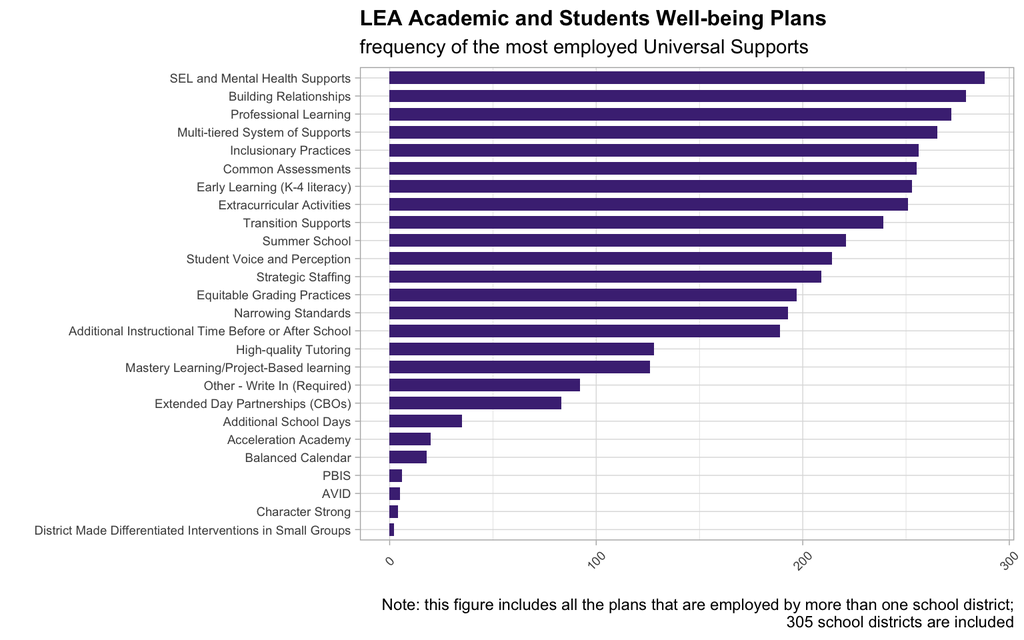

[figure not shown]

# D.3 StrategicSupport

> Summarize the frequency of the categories of “StrategicSupport”, by types of identified student groups, by unit of district (we may not see a big difference across these types of students)

All the student groups in df:

| StudentGroup |  |
| --- | --- |
| “American Indian/ Alaska Native students” | “English Language Learners” “Hispanic/Latino of any race(s) students” |
| “African American Male Students” | “All our students need some social-emotional support” |
| “Highly Capable” | “Students Furthest from Educational Justice” |
| “n/a” | “Students who are credit deficient” |
| “All students have been impacted.” | “Chronic or Extreme Chronic Absence” |
| “Gifted Students” | “High School AP & Running Start Students” |
| “Students referred by teacher” | “Students new to UPSD” |
| “Students below grade level performance targets” | “Our student group is the 43 students in K-5. We have some students requiring intervention and are providing those services.” |
| “With a total enrollment of 9 at the end of the 2020-21 school year all students were considered individually and as a group” |  |

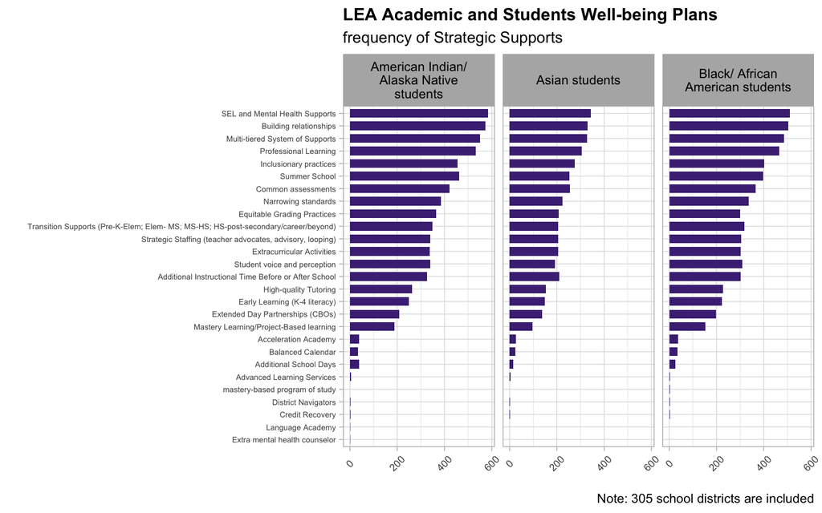

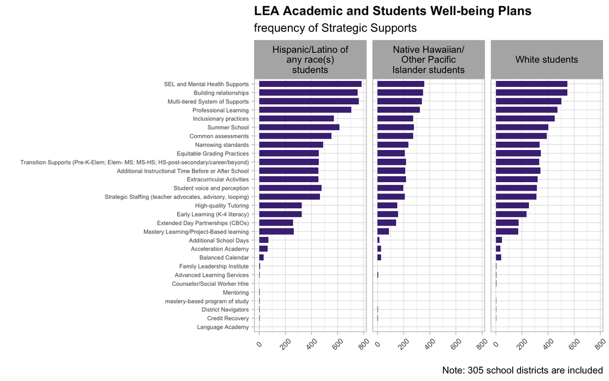

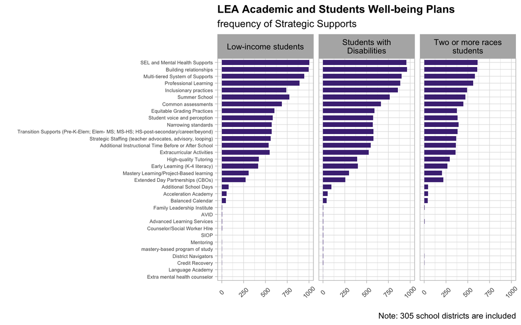

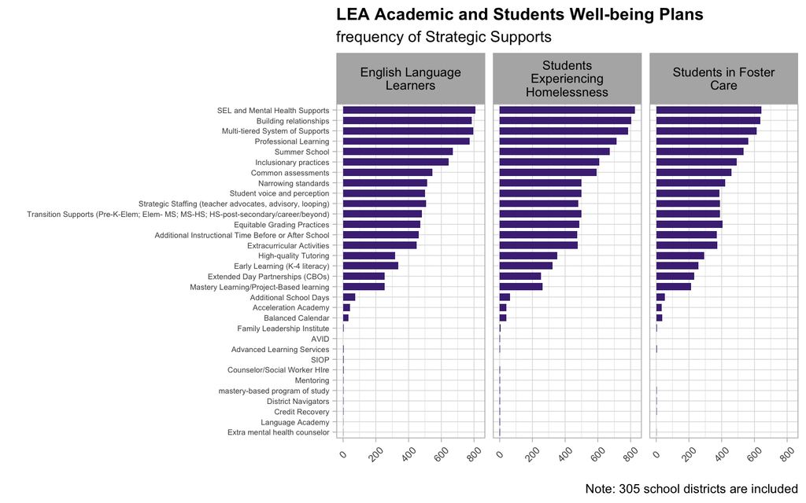

> Common student groups identified by school districts

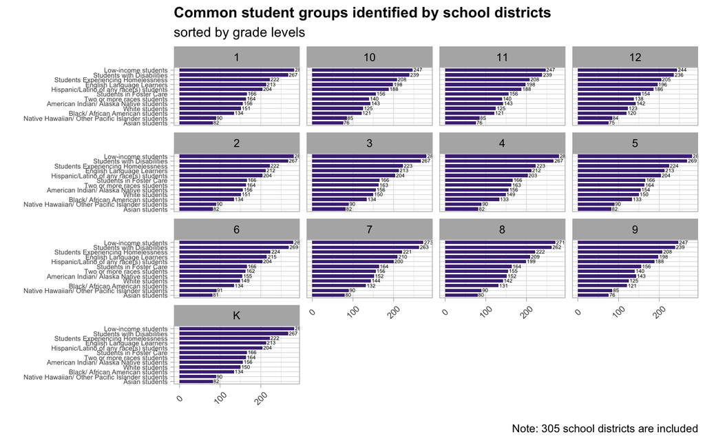

> Special student groups only used by single school district

| School Districts use special student group | * marks schools that do not use derailed race/ethnicity groups |
| --- | --- |
| “Damman School District”* | Our student group is the 43 students in K-5. We have some students requiring intervention and are providing those services. |
| “Index Elementary School District 63”* | All our students need some social-emotional support |
| “Seattle School District No. 1” | African American Male Students; Highly Capable; Students Furthest from Educational Justice |
| “Shaw Island School District”* | With a total enrollment of 9 at the end of the 2020-21 school year all students were considered individually and as a group |
| “Sultan School District” | All students have been impacted. |
| “Sumner School District” | Students who are credit deficient |
| “Tahoma School District” | Chronic or Extreme Chronic Absence |
| “Tukwila School District” | Gifted Students; High School AP & Running Start Students; Students referred by teacher |
| “University Place School District” | Students below grade level performance targets; Students new to UPSD |

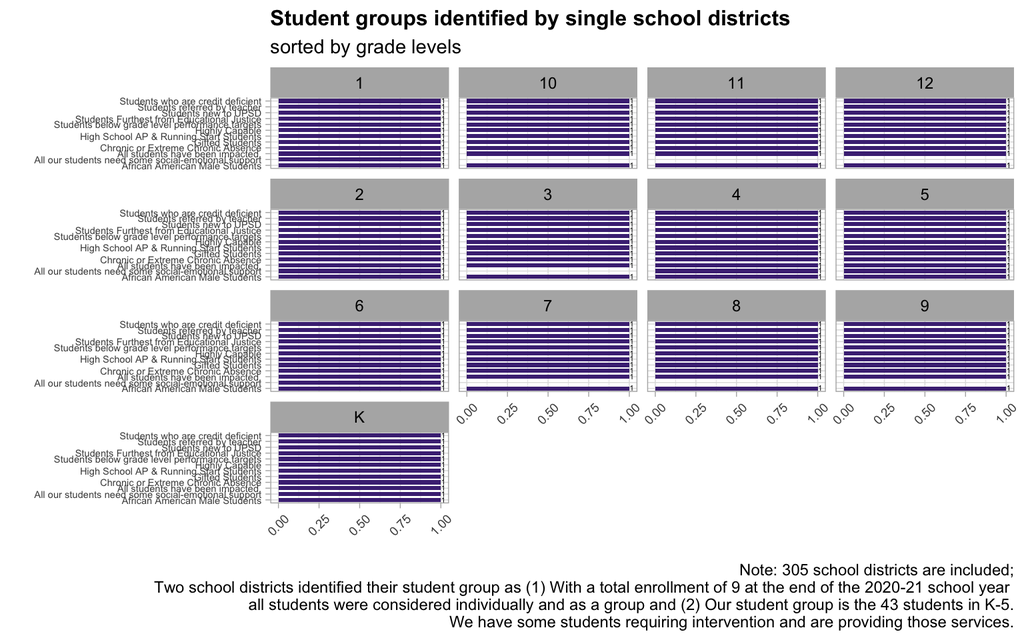

# D.4 StrategiesForMentoring & Support

## StrategiesForMentoring

> Summarize the frequency of the “strategiesformentoring”,

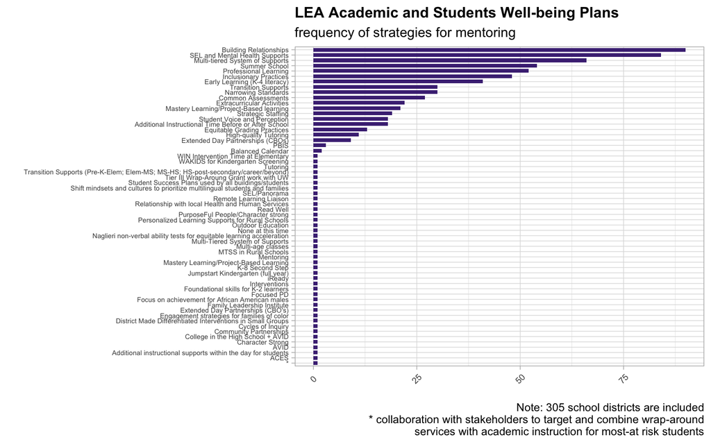

## StrategiesForSupport

> The frequency of the “strategies for support”

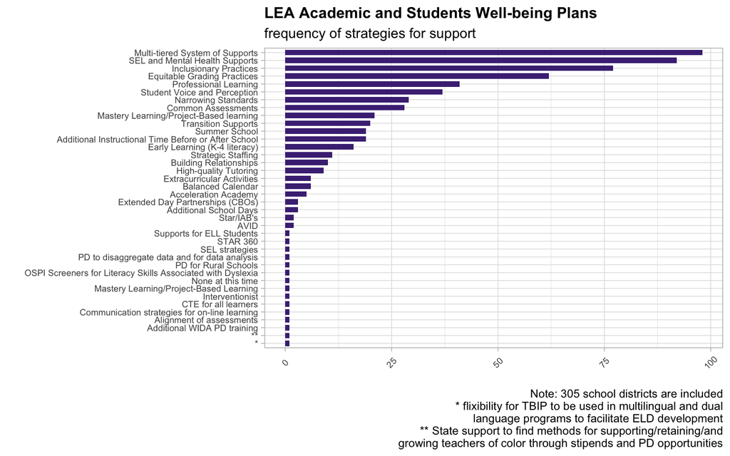